# Predicting limit for NBA Percentage Statistics

17 April 2018

## Data

- The datasets are from Basketball Reference (https://www.basketball-reference.com/).
- This website is a comprehensive source for various statistics in basketball's history, most specifically the NBA.
- The datasets consist of the top 10 NBA individual players' free throw percentages, top 10 NBA individual players' 2 point field goal percentage, and top 10 NBA individual players' 3 point percentages respectively, for each season recorded since the inception of the league 1949-2017 (68 seasons total).

## Data

- Top Free Throw Percentage for Each Season

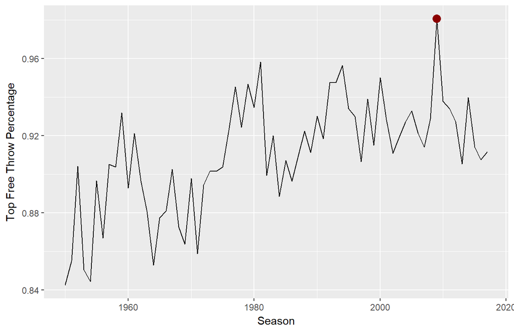

## Generalized Extreme Value Distribution (GEV)

Let \(x_{r,i}\) denote for \(i\)'s season, the \(r\)th best free throw percentage. Let \(x_{1,i} \geq x_{2,i} \geq x_{3,i} ... \geq x_{10,i}\) for \(i=1, 2, 3, ... 68\) (68 total seasons). The generalized extreme value (GEV) distribution's probability density function is defined as:

\[ \begin{align} f(x| \mu, \sigma, \xi) = \frac{1}{\sigma} \left(1+\xi \frac{x-\mu}{\sigma} \right)^{-\frac{1}{\xi}-1}e^{-\left(1+\xi \frac{x-\mu}{\sigma} \right)^{-\frac{1}{\xi}}} \end{align} \]

with support:

\[ \begin{align} X \in [\mu - \frac{\sigma}{\xi}] & \text{ when } & \xi > 0 \\ X \in (-\infty,\infty) & \text{ when } & \xi = 0 \\ X \in [\mu + \frac{\sigma}{\xi}] & \text{ when } & \xi < 0 \end{align} \]

## Generalized Extreme Value r Distribution (GEVr)

\[ f_r (x_1, x_2, ..., x_r | \mu, \sigma, \xi) = \sigma^{-r}\exp\left\{-(1+\xi z_r)^{-\frac{1}{\xi}} - \left(\frac{1}{\xi}+1\right)\sum_{j=1}^{r}\log(1+\xi z_j)\right\} \] where \(x_1 > \cdots> x_r\), \(z_j = (x_j - \mu) / \sigma\), and \(1 + \xi z_j > 0\) for \(j=1, \ldots, r\).

With support:

\[ \begin{align} X \in [\mu - \frac{\sigma}{\xi}] & \text{ when } & \xi > 0 \\ X \in (-\infty,\infty) & \text{ when } & \xi = 0 \\ X \in [\mu + \frac{\sigma}{\xi}] & \text{ when } & \xi < 0 \end{align} \]

## Generalized Extreme Value Distribution

- a special case of the GEVr distribution where r=1
- The GEV distribution takes three parameters: location \(\mu \in \mathbb{R}\), scale \(\sigma > 0\), and shape \(\xi \in \mathbb{R}\).
- Based off of the support,
  - a lower limit \(x^{*} = \mu - \frac{\sigma}{\xi}\) can be found if the shape parameter \(\xi > 0\)
  - an upper limit \(x^{*} = \mu + \frac{\sigma}{\xi}\) can be found if the shape parameter \(\xi < 0\)
- This upper limit is what is of interest for the free throw data
- This lower limit is what is of interest for the 2pt and 3pt data
- We implemented and evaluated the fit of various location parameters including an evaluated gompertz curve and a constant value.

## Constant for Location Parameter

- A constant \(k\) for the location parameter \(\mu\) is the simplest usage. \[ \begin{align} f(x) = \frac{1}{\sigma} \left(1+\xi \frac{x-k}{\sigma} \right)^{-\frac{1}{\xi}-1}e^{-\left(1+\xi \frac{x-k}{\sigma} \right)^{-\frac{1}{\xi}}} \end{align} \]
- the upper limit \(x^{*} = k + \frac{\sigma}{\xi}\) can be found if the shape parameter \(\xi < 0\)
- the lower limit \(x^{*} = k - \frac{\sigma}{\xi}\) can be found if the shape parameter \(\xi > 0\)

## Gompertz Curve for Location Parameter

The gompertz approach uses the gompertz function defined as:

\[ \begin{align} f(t)= ae^{-be^{(-ct)}} + z \end{align} \]

- The gompertz curve is a function of time \(t\)
- \(a\) is the asymptotic parameter (technically \(a+z\) is the asymptote)
- \(b\) describes where the curve is placed on the x axis
- \(c\) is the growth rate
- \(z\) is the intercept.
- \(\lim_{t \to \infty} f(t) = \lim_{t \to \infty} ae^{-be^{(-ct)}} + z = ae^{-be^{(-\infty)}} + z = ae^{0} + z = a + z\)
- Due to the asymptotic feature of the gompertz curve, I can fit a gompertz curve \(f(t)\) as the location parameter \(\mu\) of the gev distribution thus the findings do not depend on time.
  - This is unlike many time series approaches like ARIMA modeling, that use time to forecast results in the future allowing an ultimate upper limit that does not have to happen at a certain time.

## Gompertz Curve for Location Parameter

The gompertz curve implemented into the gev distribution's location parameter:

\[ \begin{align} f(x) = \frac{1}{\sigma} \left(1+\xi \frac{x-(ae^{-be^{(-ct)}} + z)}{\sigma} \right)^{-\frac{1}{\xi}-1}e^{-\left(1+\xi \frac{x-(ae^{-be^{(-ct)}} + z)}{\sigma} \right)^{-\frac{1}{\xi}}} \end{align} \]

## Functions

```r
#Gompertz function evaluates parameters using gompertz distribution
gompertz <- function(time, theta){
  theta[1] + theta[2]*exp(-theta[3]*exp(-theta[4]*time))
}

### Log likelihood function for gevr distribution using gompertz curve as location parameter
gevrloglik <- function(theta, data){
  time <- 1:NROW(data)
  mu <- gompertz(time, theta[1:4])
  if (theta[5] < 0) return(-Inf)
  log.density <- sum(dgevr(data, loc = mu, scale = theta[5], shape = theta[6], log.d=TRUE))
  return(log.density)
}
```

## Functions

```r
sim_param_constant <- function(r, boots, data, obs_par) {
  stats <- matrix(nrow=boots, ncol=(length(obs_par)+2))
  for(i in 1:boots){
    sim_data <- rep(NA, boots)
    sim_data <- rgevr(n=length(data), r = r, loc=obs_par[1],
                      scale=obs_par[2], shape=obs_par[3])
    mle_obj <- gevrFit(sim_data, method = "mle")
    mle_par <- mle_obj$par.ests
    mle_val <- mle_obj$nllh.final
    mu <- mle_par[1]
    non_loc_data = data - mu
    ks = ks.test(non_loc_data,pgev,scale=mle_par[2],shape=mle_par[3])
    stats[i,] <- c(mle_par,mle_val,ks$statistic)
  }
  return(stats)
}
```

## Functions

```r
sim_param_gom <- function(r, boots, data, obs_par) {
  stats <- matrix(nrow=boots, ncol=(length(obs_par)+2))
  for(i in 1:boots){
    sim_data <- rep(NA, boots)
    sim_data <- rgevr(n=length(data), r = r, loc=gompertz(1:length(data),obs_par[1:4]),
                      scale=obs_par[5], shape=obs_par[6])
    mle_obj <- matrix(nrow=length(data),ncol=r)
    mle_obj <- optim(obs_par,gevrloglik, data=sim_data,
                     control=list(fnscale=-1, trace=FALSE, maxit=999))
    mle_par <- mle_obj$par
    mle_val <- mle_obj$value
    time = 1:length(data)
    mu <- gompertz(time, mle_par[1:4])
    non_loc_data = data - mu
    ks = ks.test(non_loc_data,pgev,scale=mle_par[5],shape=mle_par[6])
    stats[i,] <- c(mle_par,mle_val,ks$statistic)
  }
  return(stats)
}
```

## Optimizing Parameters: Constant Top1

- Parameters for the GEV distribution are fitted to the data using maximum loglikelihood estimation (MLE) criteria and the {eva} package's "gevrFit" function.
- An ultimate upper limit is then calculated using the MLE parameters.

```r
library(eva)
source("functions.R")

mle <- gevrFit(top1[27:68,], method = "mle") #only stationary part of the data
mle

limit <- mle$par.ests[1] - mle$par.ests[2]/mle$par.ests[3]; limit
```

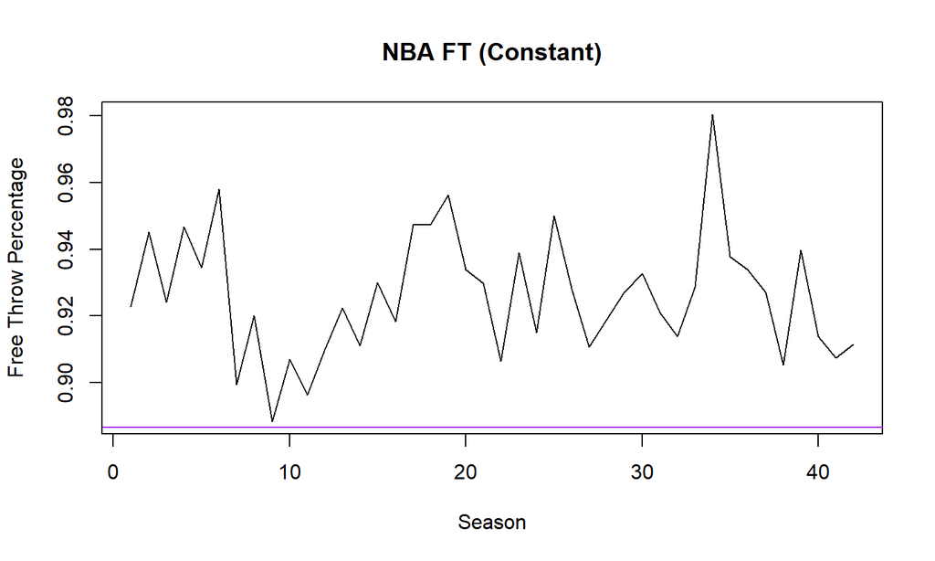

```r
ts.plot(g_dat[27:68,2], ylab="Free Throw Percentage",xlab="Season")
title("NBA FT (Constant)")
abline(h=mle$par[1], col="purple")
```

## Kolmogorov-Smirnov Test

- To evaluate goodness of fit for the gev distribution, I will use the Kolmogorov-Smirnov test.
- I cannot use the pvalue from the output of this test however because it relies on the mean from the data so instead a parametric bootstrap approach is applied with a resulting approximated pvalue.
- If the approximated pvalue is < 0.05, then it means that the distribution is not a good fit to the data
- My approach for the constant Kolmogorov_Smirnov Test is below:

## Kolmogorov-Smirnov Test

```r
mu <- mle$par[1]
non_loc_data = g_dat[27:68,2] - mu

ks = ks.test(non_loc_data,pgev,scale=mle$par[2],shape=mle$par[3]); ks
```

```
##
##  One-sample Kolmogorov-Smirnov test
##
## data:  non_loc_data
## D = 0.66931, p-value < 2.2e-16
## alternative hypothesis: two-sided
```

```r
ks$statistic
```

```
##         D
## 0.6693097
```

## Bootstrap Confidence Interval: Constant Top1

- A 95% boostrap confidence interval is calculated by running 1000 bootstraps using this same method on 1000 unique datasets randomly generated using the MLE parameters for the GEV distribution found.

```r
library(dplyr)

set.seed(12345)
values <- sim_param_constant(r=1,boots=1000,data=top1[27:68,],obs_par=mle$par.ests); values
values = as.data.frame(values)
values <- mutate(values, limit = V1 - V2/V3)


limits <- values$limit
limits <- limits[sort.list(limits)]

lb <- limits[25]; lb

ub <- limits[975]; ub
```

## Bootstrap Confidence Interval: Constant Top1

```r
head(con_values_ft)
```

```
##          V1         V2         V3       V4        V5 V6     limit
## 1 0.9582031 0.01577890 -0.3792895 114.1098 0.7441459  0 0.9998043
## 2 0.9262659 0.01886659 -0.2594071 104.4995 0.2031146  0 0.9989956
## 3 0.9453598 0.02026965 -0.3790963 102.8761 0.5405907  0 0.9988282
## 4 0.9408046 0.01696135 -0.3203158 110.3576 0.4947523  0 0.9937566
## 5 0.9663812 0.01607350 -0.4901702 115.3338 0.8268479  0 0.9991728
## 6 0.9330858 0.01792026 -0.2794273 107.2343 0.3387957  0 0.9972179
```

```r
length(con_values_ft$V5[con_values_ft$V5 >= ks$statistic])/nrow(con_values_ft) # approx. pvalue
## 0.919

hist(con_values_ft$V5,main="NBA FT (Constant): Histogram of KS Statistics",xlab="KS Statistics")
abline(v = ks$statistic, lty = 2,col="purple")
```

## Constant Top1 Goodness of Fit

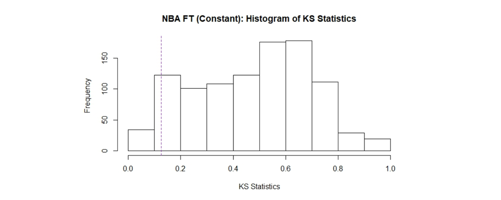

## Results

| Data | r | Method | Upper.Or.Lower | Current.Record | Limit | CI.95.Perc |
| --- | --- | --- | --- | --- | --- | --- |
| FT | 1 | Constant | Upper | 0.981 | 0.992 | (0.952,1) |

## Initial Parameters to Run Through Optimizer

```r
library(splines2)
library(eva)
library(Matrix)

df <- 6

lines1 <- iSpline(1:68, df) #all positive values
lines1 <- as.data.frame(lines1)
names(lines1) <- paste0("x",1:df)

source("functions.R")

splines_fit_nloc <- gevr_fit_nloc(g_dat[1:68,2], locvars = lines1,
                                  locform = ~ x1 + x2 + x3 + x4 + x5 + x6)

splines_fit_nloc$par.ests #all location values are pos.
```

```
## Location (Intercept)          Location x1          Location x2
##         0.8708062325         0.0126327948         0.0206960408
##          Location x3          Location x4          Location x5
##         0.0169531688         0.0021670871         0.0028668688
##          Location x6    Scale (Intercept)    Shape (Intercept)
##         0.0001270271         0.0238878742        -0.3948611535
```

## Initial Parameters to Run Through Optimizer

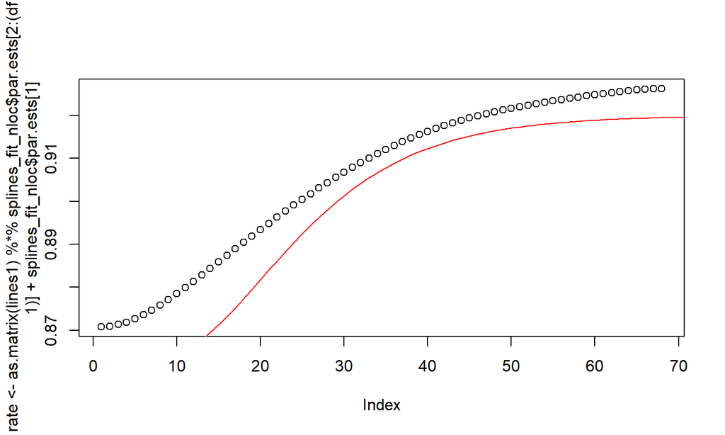

```r
plot(rate <- as.matrix(lines1) %*% splines_fit_nloc$par.ests[2:(df+1)]
     + splines_fit_nloc$par.ests[1])

# My guess at parameter values
curve(0.86 + .06* exp(-7.5 * exp(-.1*x)),0, 73, add=TRUE, col="red")
```

```r
time <- as.numeric(1:length(rate))
gom_guesses <- c(z=0.86,a=0.06, b=7.5, c=0.1)
```

## Initial Parameters to Run Through Optimizer

```r
nls_model <- nls ( rate ~ z + a*exp(-b*exp(-c*time)),trace=TRUE,start=gom_guesses)
```

```
## 0.005177871 :  0.86 0.06 7.50 0.10
## 0.003187828 :  0.8704321 0.0565386 2.1982410 0.0704715
## 9.247405e-05 :  0.86938848 0.05883562 3.17596434 0.06317256
## 2.215117e-06 :  0.86723540 0.06077357 3.30893695 0.06817614
## 2.031041e-06 :  0.86731797 0.06078366 3.33262026 0.06822770
## 2.031022e-06 :  0.86731429 0.06078824 3.33197916 0.06822173
## 2.031022e-06 :  0.86731433 0.06078819 3.33198822 0.06822180
```

```r
nls_model
```

```
## Nonlinear regression model
##   model: rate ~ z + a * exp(-b * exp(-c * time))
##    data: parent.frame()
##       z       a       b       c
## 0.86731 0.06079 3.33199 0.06822
##  residual sum-of-squares: 2.031e-06
##
## Number of iterations to convergence: 6
## Achieved convergence tolerance: 4.435e-07
```

```r
init <- c(coef(nls_model),splines_fit_nloc$par.ests[df+2],splines_fit_nloc$par.ests[df+3])
```

## Optimizing Parameters: Gompertz Top1

- Parameters for the GEV distribution are fitted to the data through the optimization method Nelder Mead using maximum loglikelihood estimation (MLE) criteria.
- An ultimate upper limit is then calculated using the MLE parameters.

```r
source("functions.R")

init <- c(coef(nls_model),splines_fit_nloc$par.ests[df+2],splines_fit_nloc$par.ests[df+3])

mle <- optim(init,gevrloglik, data=top1, control=list(fnscale=-1, trace=TRUE, maxit=999))
mle$par

gom_limit <- mle$par[1]+mle$par[2] - mle$par[5]/mle$par[6]; gom_limit
```

## Optimizing Parameters: Gompertz Top1

```r
mle$par
```

```
##                 z                 a                 b                 c
##        0.86731433        0.06078819        3.33198822        0.06822180
## Scale (Intercept) Shape (Intercept)
##        0.02388787       -0.35321130
```

```r
gom_limit_ft <- mle$par[1]+mle$par[2] - mle$par[5]/mle$par[6]; gom_limit_ft
```

```
##         z
## 0.9957331
```

```r
## 0.996
```

## Gompertz Top1 MLE fitting to the Data

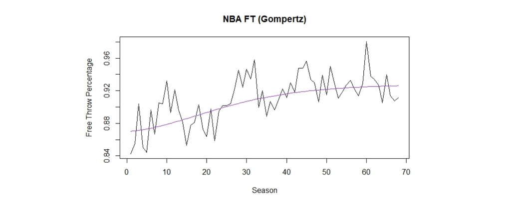

## Kolmogorov_Smirnov Test

```r
time = 1:68
mu <- gompertz(time, mle$par[1:4])
non_loc_data = g_dat[1:68,2] - mu

ks = ks.test(non_loc_data,pgev,scale=mle$par[5],shape=mle$par[6]); ks
```

```
##
##  One-sample Kolmogorov-Smirnov test
##
## data:  non_loc_data
## D = 0.13906, p-value = 0.131
## alternative hypothesis: two-sided
```

```r
ks$statistic
```

```
##        D
## 0.139061
```

```r
## 0.139061
```

## Gompertz Top1 Goodness of Fit

- approx. pvalue = 0.415

[figure not shown]

## Bootstrap Confidence Interval: Gompertz Top1

- A 95% boostrap confidence interval is calculated by running 1000 bootstraps using this same method on 1000 unique datasets randomly generated using the MLE parameters for the GEV distribution found.

```r
library(dplyr)

set.seed(12345)
values <- sim_param(r=1,boots=1000,data=top1,obs_par=mle$par); values
values = as.data.frame(values)
values <- mutate(values, limit = V1 + V2 - V5/V6)

limits <- values$limit
limits <- limits[sort.list(limits)]

lb <- limits[25]; lb

ub <- limits[975]; ub
```

## Bootstrap Confidence Interval: Gompertz Top1

```r
head(gom_values_ft)
```

```
##          V1         V2       V3         V4         V5         V6       V7
## 1 0.8734495 0.06039957 3.337726 0.06766740 0.02272453 -0.3435253 159.7150
## 2 0.8673143 0.06078819 3.331988 0.07863426 0.02388787 -0.3532113 170.3225
## 3 0.8673143 0.06078819 3.592300 0.06822180 0.02388787 -0.3532113 157.6908
## 4 0.8752946 0.05322876 3.730152 0.06704314 0.02606412 -0.5567953 161.5176
## 5 0.8630948 0.07091596 3.337331 0.06885585 0.02256289 -0.3419180 163.6414
## 6 0.8664495 0.06074156 3.665916 0.05701907 0.02363871 -0.3332490 160.4514
##           V8 V9     limit
## 1 0.22563103  0 1.0000000
## 2 0.16877099 10 0.9957331
## 3 0.11649981 10 0.9957331
## 4 0.15209418  0 0.9753343
## 5 0.17456908  0 1.0000000
## 6 0.06674193  0 0.9981252
```

## Results

| Data | r | Method | Upper.Or.Lower | Current.Record | Limit | CI.95.Perc |
| --- | --- | --- | --- | --- | --- | --- |
| FT | 1 | Constant | Upper | 0.981 | 0.992 | (0.952,1) |
| FT | 1 | Gompertz | Upper | 0.981 | 0.996 | (0.969,1) |

## Optimizing Parameters: Gompertz Top3

- Parameters for the GEV distribution are fitted to the data through the optimization method Nelder Mead using maximum loglikelihood estimation (MLE) criteria.
- An ultimate upper limit is then calculated using the MLE parameters.

```r
source("functions.R")

mle <- optim(init,gevrloglik, data=top3, control=list(fnscale=-1, trace=TRUE, maxit=999))
mle$par

gom_limit_ft_top3 <- mle$par[1]+mle$par[2] - mle$par[5]/mle$par[6]; gom_limit_ft_top3
```

## Optimizing Parameters: Gompertz Top3

```r
mle
```

```
## $par
##                 z                 a                 b                 c
##        0.87189285        0.06056206        5.53162775        0.07542787
## Scale (Intercept) Shape (Intercept)
##        0.02265565       -0.36072380
##
## $value
## [1] 625.1386
##
## $counts
## function gradient
##       45       NA
##
## $convergence
## [1] 10
##
## $message
## NULL
```

```r
gom_limit_ft_top3 <- mle$par[1]+mle$par[2] - mle$par[5]/mle$par[6]; gom_limit_ft_top3
```

```
##        z
## 0.995261
```

```r
## 0.995
```

## Bootstrap Confidence Interval: Gompertz Top3

- A 95% boostrap confidence interval is calculated by running 1000 bootstraps using this same method on 1000 unique datasets randomly generated using the MLE parameters for the GEV distribution found.

```r
library(dplyr)

set.seed(12345)
values <- sim_param(r=3,boots=1000,data=top3,obs_par=mle$par); values
values = as.data.frame(values)
values <- mutate(values, limit = V1 + V2 - V5/V6)

limits <- values$limit
limits <- limits[sort.list(limits)]

lb <- limits[25]; lb

ub <- limits[975]; ub
```

## Gompertz Top3 MLE fitting to the Data

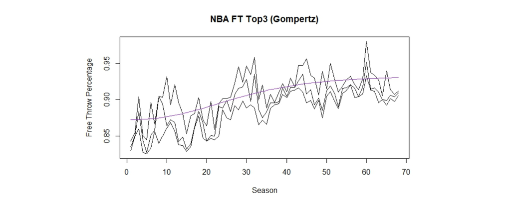

## Gompertz Top3 Goodness of Fit

- approx. pvalue = 0.421

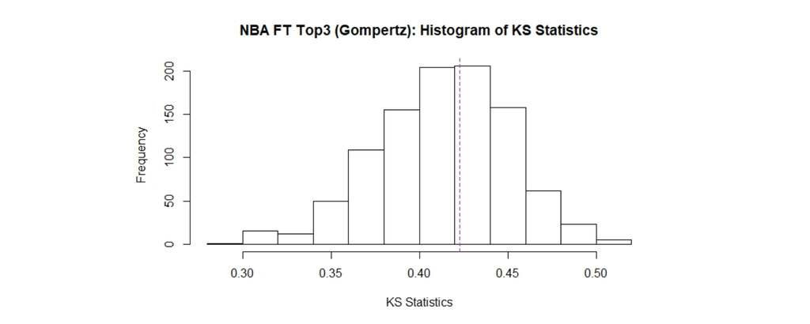

## Results

| Data | r | Method | Upper.Or.Lower | Current.Record | Limit | CI.95.Perc |
| --- | --- | --- | --- | --- | --- | --- |
| FT | 1 | Constant | Upper | 0.981 | 0.992 | (0.952,1) |
| FT | 1 | Gompertz | Upper | 0.981 | 0.996 | (0.969,1) |
| FT | 3 | Constant | Upper | 0.981 | 0.997 | (0.960,1) |
| FT | 3 | Gompertz | Upper | 0.981 | 0.995 | (0.975,1) |

## Constant 3pt MLE fitting to the Data

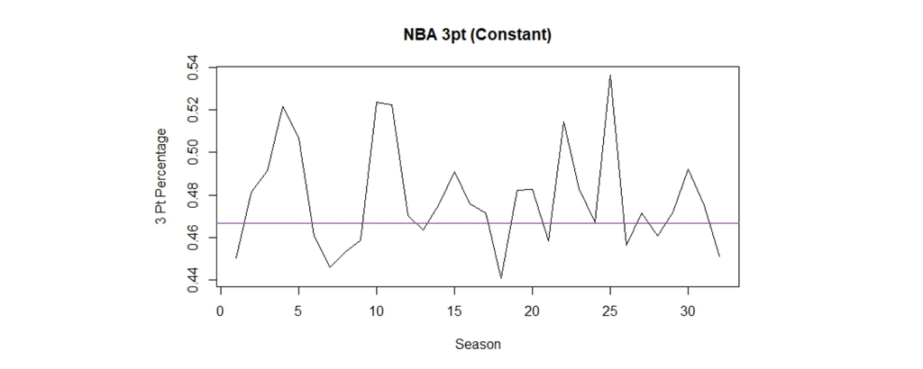

## Constant 3pt Goodness of Fit

- approx. pvalue = 0.989

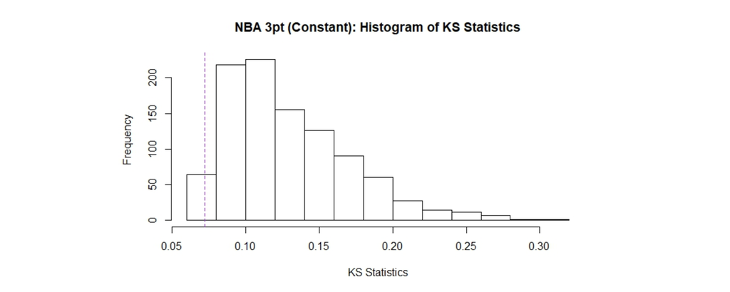

## Results

| Data | r | Method | Upper.Or.Lower | Current.Record | Limit | CI.95.Perc |
| --- | --- | --- | --- | --- | --- | --- |
| FT | 1 | Constant | Upper | 0.981 | 0.992 | (0.952,1) |
| FT | 1 | Gompertz | Upper | 0.981 | 0.996 | (0.969,1) |
| FT | 3 | Constant | Upper | 0.981 | 0.997 | (0.960,1) |
| FT | 3 | Gompertz | Upper | 0.981 | 0.995 | (0.975,1) |
| 3pt | 1 | Constant | Lower | 0.441 | 0.325 | (0.045,0.427) |

## Gompertz 2pt MLE fitting to the Data

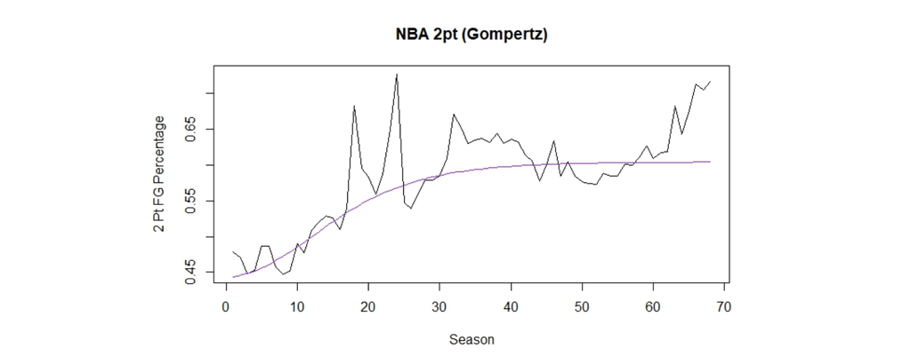

## Gompertz 2pt Goodness of Fit

- approx. pvalue = 0.961

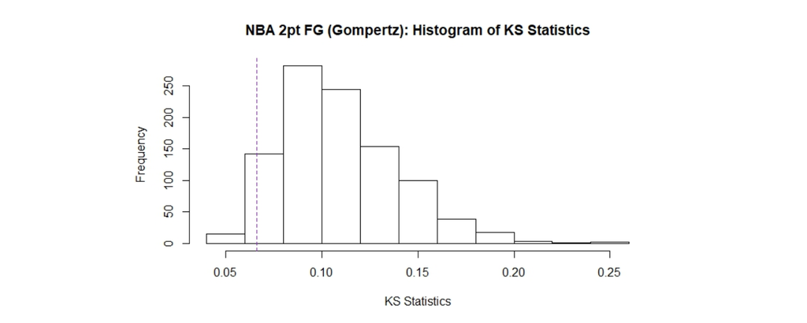

## Results

| Data | r | Method | Upper.Or.Lower | Current.Record | Limit | CI.95.Perc |
| --- | --- | --- | --- | --- | --- | --- |
| FT | 1 | Constant | Upper | 0.981 | 0.992 | (0.952,1) |
| FT | 1 | Gompertz | Upper | 0.981 | 0.996 | (0.969,1) |
| FT | 3 | Constant | Upper | 0.981 | 0.997 | (0.960,1) |
| FT | 3 | Gompertz | Upper | 0.981 | 0.995 | (0.975,1) |
| 3pt | 1 | Constant | Lower | 0.441 | 0.325 | (0.045,0.427) |
| 2pt | 1 | Gompertz | Lower | 0.447 | 0.429 | (0.001,0.544) |

## Some Helpful Resources

- basketball statistics website:
  - https://www.basketball-reference.com/
- {eva} R package:
  - https://cran.r-project.org/web/packages/eva/eva.pdf